# Supervised Learning Classification Project: AllLife Bank Personal Loan Campaign

## Problem Statement

### Context

AllLife Bank is a US bank that has a growing customer base. The majority of these customers are liability customers (depositors) with varying sizes of deposits. The number of customers who are also borrowers (asset customers) is quite small, and the bank is interested in expanding this base rapidly to bring in more loan business and in the process, earn more through the interest on loans. In particular, the management wants to explore ways of converting its liability customers to personal loan customers (while retaining them as depositors).

A campaign that the bank ran last year for liability customers showed a healthy conversion rate of over 9% success. This has encouraged the retail marketing department to devise campaigns with better target marketing to increase the success ratio.

You as a Data scientist at AllLife bank have to build a model that will help the marketing department to identify the potential customers who have a higher probability of purchasing the loan.

### Objective

To predict whether a liability customer will buy personal loans, to understand which customer attributes are most significant in driving purchases, and identify which segment of customers to target more.

### Data Dictionary

- `ID`: Customer ID
- `Age`: Customer’s age in completed years
- `Experience`: #years of professional experience
- `Income`: Annual income of the customer (in thousand dollars)
- `ZIP Code`: Home Address ZIP code.
- `Family`: the Family size of the customer
- `CCAvg`: Average spending on credit cards per month (in thousand dollars)
- `Education`: Education Level. 1: Undergrad; 2: Graduate;3: Advanced/Professional
- `Mortgage`: Value of house mortgage if any. (in thousand dollars)
- `Personal_Loan`: Did this customer accept the personal loan offered in the last campaign? (0: No, 1: Yes)
- `Securities_Account`: Does the customer have securities account with the bank? (0: No, 1: Yes)
- `CD_Account`: Does the customer have a certificate of deposit (CD) account with the bank? (0: No, 1: Yes)
- `Online`: Do customers use internet banking facilities? (0: No, 1: Yes)
- `CreditCard`: Does the customer use a credit card issued by any other Bank (excluding All life Bank)? (0: No, 1: Yes)

## Importing necessary libraries

```python
# import libraries for data manipulation
import numpy as np
import pandas as pd

# import libraries for data visualization
import matplotlib.pyplot as plt
import seaborn as sns

# import library to split data
from sklearn.model_selection import train_test_split

# import libraries to build model for prediction
from sklearn.linear_model import LogisticRegression
from sklearn.tree import DecisionTreeClassifier
from sklearn import tree

# import libraries to tune different models
from sklearn.model_selection import GridSearchCV

# import libraries to get diferent metric scores
from sklearn.metrics import (
    f1_score,
    accuracy_score,
    recall_score,
    precision_score,
    confusion_matrix,
    roc_auc_score,
    #plot_confusion_matrix,# plot_confusion_matrix has been replaced with ConfusionMatrixDisplay
    ConfusionMatrixDisplay,
    precision_recall_curve,
    roc_curve,
    make_scorer,
)
```

```python
# defining the filename and feature names in UPPERCASE for readability.
# loan modelling csv file
CSV_FILE='Loan_Modelling.csv'

# features
ID='ID'
AGE='Age'
EXPERIENCE='Experience'
INCOME='Income'
ZIPCODE='ZIPCode'
FAMILY='Family'
CCAVG='CCAvg'
EDUCATION='Education'
MORTGAGE='Mortgage'
PERSONAL_LOAN='Personal_Loan'
SECURITIES_ACCOUNT='Securities_Account'
CD_ACCOUNT='CD_Account'
ONLINE='Online'
CREDITCARD='CreditCard'
```

## Loading the dataset

```python
# uncomment and run the following lines for Google Colab
# from google.colab import drive
# drive.mount('/content/drive')
```

```python
# read the csv file from current folder
df_pers_loan = pd.read_csv(CSV_FILE)
```

```python
# taking a copy just in case
df_raw=df_pers_loan.copy()
```

## Data Overview

- Observations
- Sanity checks

### 1. Shape of the data

```python
# shape function returns the rows and columns as tuple.
# for better formatting reading the rows and columns separately
rows=df_raw.shape[0]
columns=df_raw.shape[1]
print(rows, 'rows and', columns,'columns are present in the data')
```

```
5000 rows and 14 columns are present in the data
```

#### Observations: The DataFrame has 5000 rows and 14 columns.

### 2. Head - First 5 rows of the data

```python
# head function to show the first 5 rows of the data
df_raw.head(5)
```

|  | ID | Age | Experience | Income | ZIPCode | Family | CCAvg | Education | Mortgage | Personal_Loan | Securities_Account | CD_Account | Online | CreditCard |
| --- | --- | --- | --- | --- | --- | --- | --- | --- | --- | --- | --- | --- | --- | --- |
| 0 | 1 | 25 | 1 | 49 | 91107 | 4 | 1.6 | 1 | 0 | 0 | 1 | 0 | 0 | 0 |
| 1 | 2 | 45 | 19 | 34 | 90089 | 3 | 1.5 | 1 | 0 | 0 | 1 | 0 | 0 | 0 |
| 2 | 3 | 39 | 15 | 11 | 94720 | 1 | 1.0 | 1 | 0 | 0 | 0 | 0 | 0 | 0 |
| 3 | 4 | 35 | 9 | 100 | 94112 | 1 | 2.7 | 2 | 0 | 0 | 0 | 0 | 0 | 0 |
| 4 | 5 | 35 | 8 | 45 | 91330 | 4 | 1.0 | 2 | 0 | 0 | 0 | 0 | 0 | 1 |

### 3. Tail - Last 5 rows of the data

```python
# tail function to show the last 5 rows of the data
df_raw.tail(5)
```

|  | ID | Age | Experience | Income | ZIPCode | Family | CCAvg | Education | Mortgage | Personal_Loan | Securities_Account | CD_Account | Online | CreditCard |
| --- | --- | --- | --- | --- | --- | --- | --- | --- | --- | --- | --- | --- | --- | --- |
| 4995 | 4996 | 29 | 3 | 40 | 92697 | 1 | 1.9 | 3 | 0 | 0 | 0 | 0 | 1 | 0 |
| 4996 | 4997 | 30 | 4 | 15 | 92037 | 4 | 0.4 | 1 | 85 | 0 | 0 | 0 | 1 | 0 |
| 4997 | 4998 | 63 | 39 | 24 | 93023 | 2 | 0.3 | 3 | 0 | 0 | 0 | 0 | 0 | 0 |
| 4998 | 4999 | 65 | 40 | 49 | 90034 | 3 | 0.5 | 2 | 0 | 0 | 0 | 0 | 1 | 0 |
| 4999 | 5000 | 28 | 4 | 83 | 92612 | 3 | 0.8 | 1 | 0 | 0 | 0 | 0 | 1 | 1 |

### 4. data types of the columns

```python
# info function to show the data types of the columns
df_raw.info()
```

```
<class 'pandas.core.frame.DataFrame'>
RangeIndex: 5000 entries, 0 to 4999
Data columns (total 14 columns):
 #   Column              Non-Null Count  Dtype
---  ------              --------------  -----
 0   ID                  5000 non-null   int64
 1   Age                 5000 non-null   int64
 2   Experience          5000 non-null   int64
 3   Income              5000 non-null   int64
 4   ZIPCode             5000 non-null   int64
 5   Family              5000 non-null   int64
 6   CCAvg               5000 non-null   float64
 7   Education           5000 non-null   int64
 8   Mortgage            5000 non-null   int64
 9   Personal_Loan       5000 non-null   int64
 10  Securities_Account  5000 non-null   int64
 11  CD_Account          5000 non-null   int64
 12  Online              5000 non-null   int64
 13  CreditCard          5000 non-null   int64
dtypes: float64(1), int64(13)
memory usage: 547.0 KB
```

### Observations: There are attributes of 2 different types such as int64(13) and float64(1) in the data.

```
1. following column(s) of the data type int64
    ID
    Age
    Experience
    Income
    ZIPCode
    Family
    Education
    Mortgage
    Personal_Loan
    Securities_Account
    CD_Account
    Online
    CreditCard
2. following column(s) of the data type float64
    CCAvg
3. Memory Usage is 547.0 KB
```

### 5. Statistical summary of the data

```python
# describe function to show statistical summary of the data.
# For readability used Transpose(.T)
df_raw.describe().T
```

|  | count | mean | std | min | 25% | 50% | 75% | max |
| --- | --- | --- | --- | --- | --- | --- | --- | --- |
| ID | 5000.0 | 2500.500000 | 1443.520003 | 1.0 | 1250.75 | 2500.5 | 3750.25 | 5000.0 |
| Age | 5000.0 | 45.338400 | 11.463166 | 23.0 | 35.00 | 45.0 | 55.00 | 67.0 |
| Experience | 5000.0 | 20.104600 | 11.467954 | -3.0 | 10.00 | 20.0 | 30.00 | 43.0 |
| Income | 5000.0 | 73.774200 | 46.033729 | 8.0 | 39.00 | 64.0 | 98.00 | 224.0 |
| ZIPCode | 5000.0 | 93169.257000 | 1759.455086 | 90005.0 | 91911.00 | 93437.0 | 94608.00 | 96651.0 |
| Family | 5000.0 | 2.396400 | 1.147663 | 1.0 | 1.00 | 2.0 | 3.00 | 4.0 |
| CCAvg | 5000.0 | 1.937938 | 1.747659 | 0.0 | 0.70 | 1.5 | 2.50 | 10.0 |
| Education | 5000.0 | 1.881000 | 0.839869 | 1.0 | 1.00 | 2.0 | 3.00 | 3.0 |
| Mortgage | 5000.0 | 56.498800 | 101.713802 | 0.0 | 0.00 | 0.0 | 101.00 | 635.0 |
| Personal_Loan | 5000.0 | 0.096000 | 0.294621 | 0.0 | 0.00 | 0.0 | 0.00 | 1.0 |
| Securities_Account | 5000.0 | 0.104400 | 0.305809 | 0.0 | 0.00 | 0.0 | 0.00 | 1.0 |
| CD_Account | 5000.0 | 0.060400 | 0.238250 | 0.0 | 0.00 | 0.0 | 0.00 | 1.0 |
| Online | 5000.0 | 0.596800 | 0.490589 | 0.0 | 0.00 | 1.0 | 1.00 | 1.0 |
| CreditCard | 5000.0 | 0.294000 | 0.455637 | 0.0 | 0.00 | 0.0 | 1.00 | 1.0 |

Observations:

1. The age of the customers

   ```
    Minimum is 23.
    Maximum is 67.
   ```

2. Annual income of the customers

   ```
    Minimum is 8 thousand dollars.
    Maximum is 224 thousand dollars.
   ```

3. Education Level

   ```
    Minimum is Undergrad(1).
    Maximum is Advanced/Professional(3).
   ```

4. Family Size

   ```
    Minimum is 1.
    Maximum is 4.
   ```

5. Mortgage

   ```
    Minimum is 0 dollars.
    Maximum is 635 thousand dollars.
   ```

### 6. Drop the ID Column

```python
# ID is not a significant column/less weighted parameter for the personal loan campaign. Hence dropping it.
# drop function to drop the column 'ID'. setting the axis = 1.
df=df_raw.drop(ID, axis=1)
```

```python
# check the info of the data after dropping the column 'ID' to confirm the drop is successful.
df.info()
```

```
<class 'pandas.core.frame.DataFrame'>
RangeIndex: 5000 entries, 0 to 4999
Data columns (total 13 columns):
 #   Column              Non-Null Count  Dtype
---  ------              --------------  -----
 0   Age                 5000 non-null   int64
 1   Experience          5000 non-null   int64
 2   Income              5000 non-null   int64
 3   ZIPCode             5000 non-null   int64
 4   Family              5000 non-null   int64
 5   CCAvg               5000 non-null   float64
 6   Education           5000 non-null   int64
 7   Mortgage            5000 non-null   int64
 8   Personal_Loan       5000 non-null   int64
 9   Securities_Account  5000 non-null   int64
 10  CD_Account          5000 non-null   int64
 11  Online              5000 non-null   int64
 12  CreditCard          5000 non-null   int64
dtypes: float64(1), int64(12)
memory usage: 507.9 KB
```

### Observations:

1. The column 'ID' is dropped.
2. Now the total number of columns is 13.
3. After dropping the column 'ID', the memory usage is now reduced to 507.9 KB from 547.0 KB.

## Data Preprocessing

### 1. Checking for missing values

```python
# checking for missing values if any
df.isnull().sum()
```

```
Age                   0
Experience            0
Income                0
ZIPCode               0
Family                0
CCAvg                 0
Education             0
Mortgage              0
Personal_Loan         0
Securities_Account    0
CD_Account            0
Online                0
CreditCard            0
dtype: int64
```

### Observation:

There are no missing values in the data.

```python
# checking the number of unique values in each column
df.nunique()
```

```
Age                    45
Experience             47
Income                162
ZIPCode               467
Family                  4
CCAvg                 108
Education               3
Mortgage              347
Personal_Loan           2
Securities_Account      2
CD_Account              2
Online                  2
CreditCard              2
dtype: int64
```

### 2. Checking for Anomalous Values

```python
# Mapping the values
#      1 - Undergrad,  2 - Graduate,  3 - Advanced/Professional
# using inplace=True for making the change to data/df
df[EDUCATION].replace(1, 'Undergraduate', inplace=True)
df[EDUCATION].replace(2, 'Graduate', inplace=True)
df[EDUCATION].replace(3, 'Professional', inplace=True)
```

### 3. Treating the negative values of the feature 'Experience'

```python
# check unique negative values
df[df[EXPERIENCE]<0][EXPERIENCE].unique()
```

```
array([-1, -2, -3])
```

```python
# negative values count before replacing
df[df[EXPERIENCE]<0][EXPERIENCE].count()
```

```
52
```

```python
# Experience values cannot be -1, -2, -3 etc.
# The negative values may be the data input errors. Hence replacing them with positive values.
# list all if Experience < 0
# df[df['Experience'] < 0]['Experience'].unique()
# replacing the negative Experience values
# using inplace=True for making the change to data df
df[EXPERIENCE].replace(-1, 1, inplace=True)
df[EXPERIENCE].replace(-2, 2, inplace=True)
df[EXPERIENCE].replace(-3, 3, inplace=True)
```

```python
# negative values count after replacing
df[df[EXPERIENCE]<0][EXPERIENCE].count()
```

```
0
```

```python
# number of unique in the ZIPCode
df[ZIPCODE].nunique()
```

```
467
```

```python
df[ZIPCODE] = df[ZIPCODE].astype(str)
print(
    'Number of unique values if we take only the first two digits of ZIPCode: ',
    df[ZIPCODE].str[0:2].nunique(),
)
df[ZIPCODE] = df[ZIPCODE].str[0:2]
```

```
Number of unique values if we take only the first two digits of ZIPCode:  7
```

### 4. Converting the data type of categorical features to 'category'

```python
# list all columns that needs to be converted as category
columns = [
    CD_ACCOUNT,
    CREDITCARD,
    EDUCATION,
    ONLINE,
    PERSONAL_LOAN,
    SECURITIES_ACCOUNT,
    ZIPCODE,
]
df[columns] = df[columns].astype('category')
```

```python
# checking if the data type changes are taken place in the data
df.info()
```

```
<class 'pandas.core.frame.DataFrame'>
RangeIndex: 5000 entries, 0 to 4999
Data columns (total 13 columns):
 #   Column              Non-Null Count  Dtype
---  ------              --------------  -----
 0   Age                 5000 non-null   int64
 1   Experience          5000 non-null   int64
 2   Income              5000 non-null   int64
 3   ZIPCode             5000 non-null   category
 4   Family              5000 non-null   int64
 5   CCAvg               5000 non-null   float64
 6   Education           5000 non-null   category
 7   Mortgage            5000 non-null   int64
 8   Personal_Loan       5000 non-null   category
 9   Securities_Account  5000 non-null   category
 10  CD_Account          5000 non-null   category
 11  Online              5000 non-null   category
 12  CreditCard          5000 non-null   category
dtypes: category(7), float64(1), int64(5)
memory usage: 269.8 KB
```

### Observations:

1. data types summary
   - category - 7 features.
   - float64 - 1 feature.
   - int64 - 5 features.
2. After converting the data type of categorical features to 'category', the memory usage is reduced to 269.8 KB.

## Exploratory Data Analysis.

### Univariate Analysis - Explore all the variables

```python
# function to create labeled barplots
def labeled_barplot(data, feature, perc=False, n=None):
    '''
    Barplot with percentage at the top

    data: dataframe
    feature: dataframe column
    perc: whether to display percentages instead of count (default is False)
    n: displays the top n category levels (default is None, i.e., display all levels)
    '''

    total = len(data[feature])  # length of the column
    count = data[feature].nunique()
    if n is None:
        plt.figure(figsize=(count + 1, 5))
    else:
        plt.figure(figsize=(n + 1, 5))

    plt.xticks(rotation=90, fontsize=15)
    ax = sns.countplot(
        data=data,
        x=feature,
        palette='Paired',
        order=data[feature].value_counts().index[:n].sort_values(),
    )

    for p in ax.patches:
        if perc == True:
            label = "{:.1f}%".format(
                100 * p.get_height() / total
            )  # percentage of each class of the category
        else:
            label = p.get_height()  # count of each level of the category

        x = p.get_x() + p.get_width() / 2  # width of the plot
        y = p.get_height()  # height of the plot

        ax.annotate(
            label,
            (x, y),
            ha='center',
            va='center',
            size=12,
            xytext=(0, 5),
            textcoords='offset points',
        )  # annotate the percentage

    plt.show()  # show the plot
```

```python
# df.groupby('Age').count()
min_age=df['Age'].min()
max_age=df['Age'].max()
# get number of unique 'Age' groups
age_uniq=df['Age'].nunique()

def histogram_boxplot(data, feature, figsize=(12, 7), kde=False, bins=None):
    '''
    Boxplot and histogram combined

    data: dataframe
    feature: dataframe column
    figsize: size of figure (default (12,7))
    kde: whether to show the density curve (default False)
    bins: number of bins for histogram (default None)
    '''
    f2, (ax_box2, ax_hist2) = plt.subplots(
        nrows=2,  # Number of rows of the subplot grid= 2
        sharex=True,  # x-axis will be shared among all subplots
        gridspec_kw={'height_ratios': (0.25, 0.75)},
        figsize=figsize,
    )  # creating the 2 subplots
    sns.boxplot(
        data=data, x=feature, ax=ax_box2, showmeans=True, color='violet'
    )  # boxplot will be created and a star will indicate the mean value of the column
    sns.histplot(
        data=data, x=feature, kde=kde, ax=ax_hist2, bins=bins, palette='winter'
    ) if bins else sns.histplot(
        data=data, x=feature, kde=kde, ax=ax_hist2
    )  # For histogram
    ax_hist2.axvline(
        data[feature].mean(), color='green', linestyle='--'
    )  # Add mean to the histogram
    ax_hist2.axvline(
        data[feature].median(), color='black', linestyle='-'
    )  # Add median to the histogram
```

### 1. Feature 'Age'

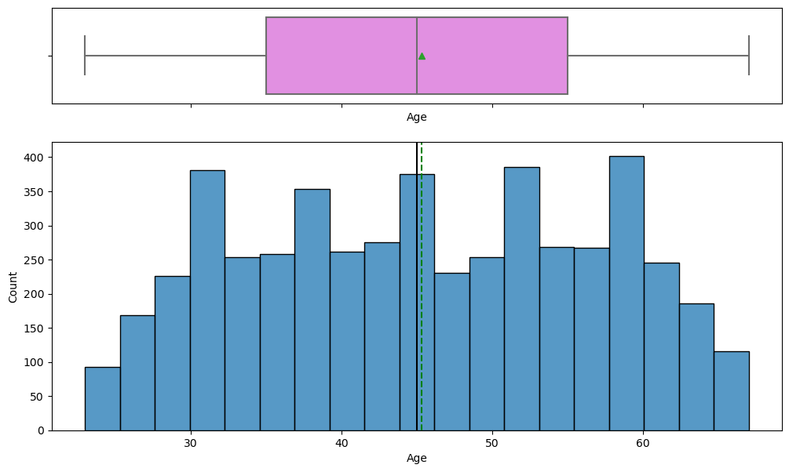

```python
# histogram boxplot
histogram_boxplot(df, AGE)
```

#### Observations on 'Age'

1. The avg age is around 45.
2. The min age is 23 and max is 67.

### 2. Feature 'Experience'

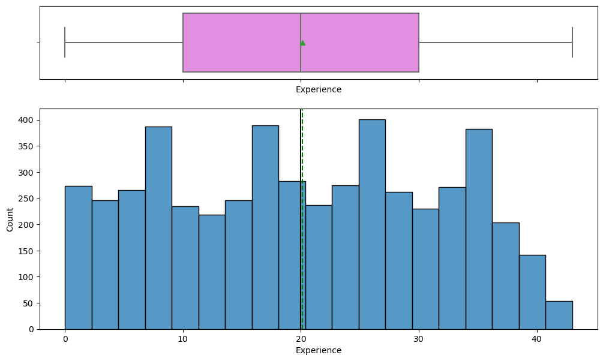

```python
# histogram boxplot
histogram_boxplot(df, EXPERIENCE)
```

### Observations on 'Experience'

#### Observations:

1. The average years of experience is around 20 years.
2. There are less number of customers with 40 and above years of experience.

### 3. Feature 'Income'

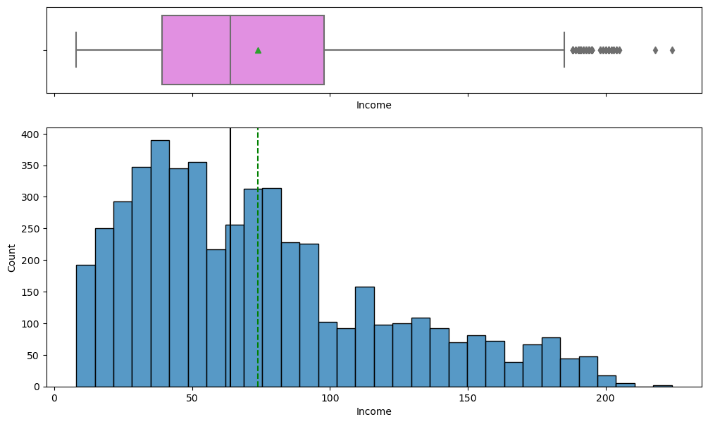

```python
# histogram boxplot
histogram_boxplot(df, INCOME)
```

### Observations on 'Income'

1. The Income is right skewed
2. The number of customers with income 200k and above is less when compared to 100k+.
3. There are more number of customers with the salary of 100k and below.
4. There are outliers in the above plot.

### 4. Feature 'ZIPCode'

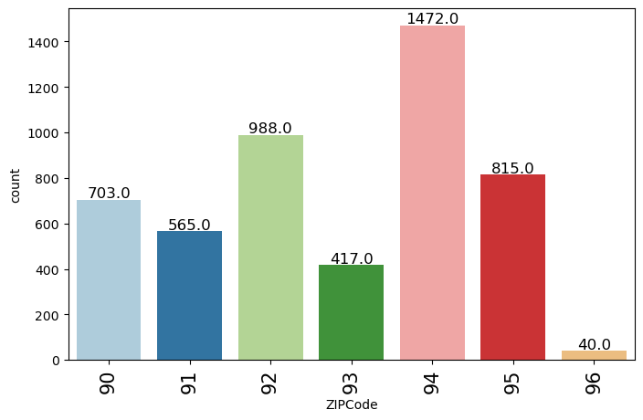

```python
# labeled barplot with count
labeled_barplot(df, ZIPCODE)
```

### Observations on 'ZIPCode'

1. There are less number of customers with the zipcode that starts with 96
2. There are 1472 customers(which is the highest) live in the zipcode that starts with 94

### 5. Feature 'Family'

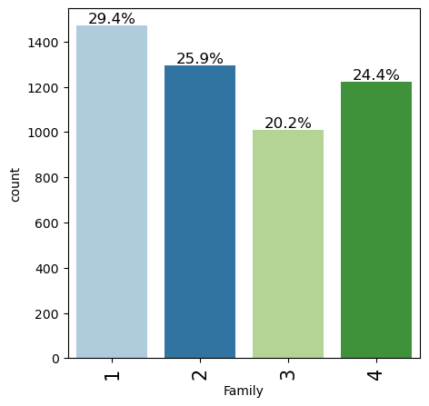

```python
# labeled barplot with percentage
labeled_barplot(df, FAMILY, perc=True)
```

### Observations on 'Family'

1. There are 29.4% of the customers with family size 1.
2. There are 25.9% of the customers with family size 2.
3. 24.4% of the customers with family size 4.
4. 20.2% of the customers with family size 3.

### 6. Feature 'CCAvg'

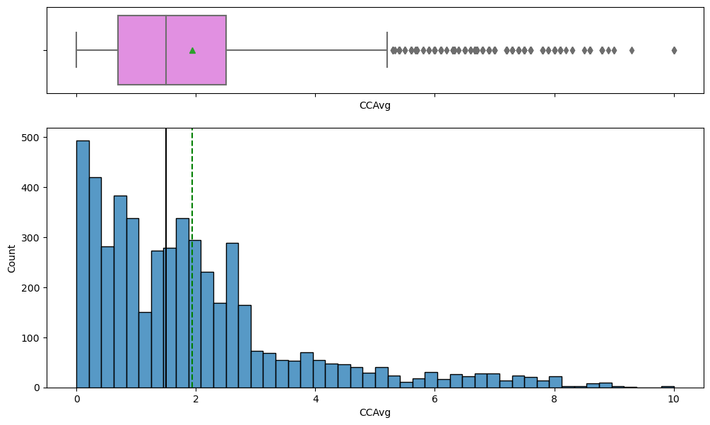

```python
# histogram_boxplot
histogram_boxplot(df, CCAVG)
```

### Observations on 'CCAvg'

1. CCAvg is right skewed.
2. There are less customers as the CCAvg (in thousand dollars/per month) increases.

### 7. Feature 'Education'

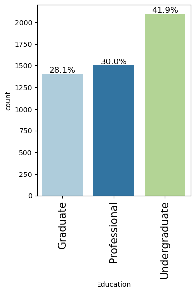

```python
# labeled barplot with percentage
labeled_barplot(df, EDUCATION, perc=True)
```

### Observations on 'Education'

1. Education plot is left skewed.
2. 41.9% of customers are Undergraduate. 30% are Professional and 28.1% are Graduate.
3. Graduates and Professionals can be targetted first followed by undergraduates.

### 8. Feature 'Mortgage'

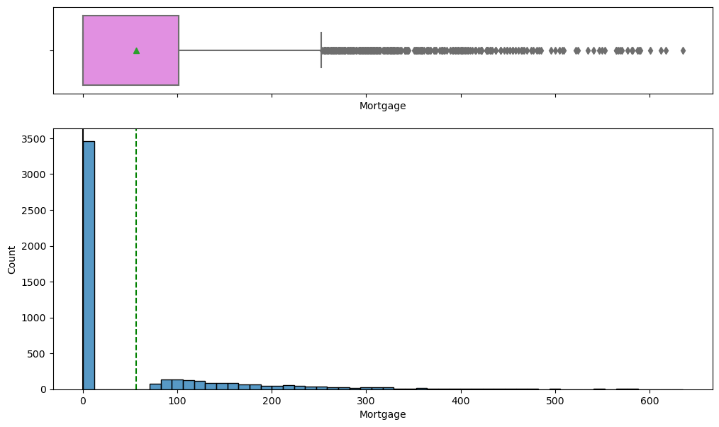

```python
# histogram_boxplot
histogram_boxplot(df, MORTGAGE)
```

### Observations on 'Mortgage'

1. Mortagage is Right Skewed.
2. There are outliers.
3. There are less number of customers with Mortgage 400k and above.

### 9. Feature 'PersonalLoan'

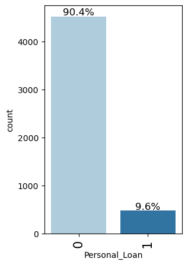

```python
# labeled barplot with percentage
labeled_barplot(df, PERSONAL_LOAN, perc=True) # 0 is NO. 1 is Yes
```

### Observations on 'Personal_Loan'

1. There are 9.6% of the customers with existing Personal Loan.
2. 90.4% of the customers with NO Personal Loan. These customers needs to be targetted first in our Personal Loan Campaign.

### 10. Feature 'Securities Account'

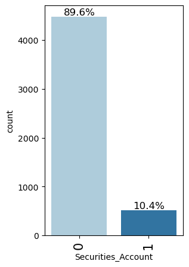

```python
# labeled barplot with percentage
labeled_barplot(df, SECURITIES_ACCOUNT, perc=True) # 0 is NO. 1 is Yes
```

### Observations on 'Securities Account'

1. There are 10.4% of the customers with Securities Account.
2. There are 89.6% of the customers with NO Securities Account.

### 11 Feature 'CD Account'

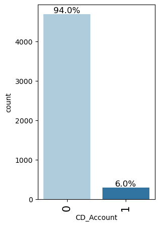

```python
# labeled barplot with percentage
labeled_barplot(df, CD_ACCOUNT, perc=True)# 0 is NO. 1 is Yes
```

### Observations on 'CD Account'

1. 94% of the customers do not have a certificate of deposit (CD) account with the bank.
2. 6% of the customers have a certificate of deposit (CD) account with the bank. These customers may/may not need personal loan.

### 12 Feature 'Online'

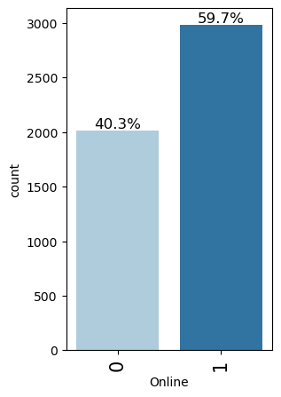

```python
# labeled barplot with percentage
labeled_barplot(df, ONLINE, perc=True) # 0 is NO. 1 is Yes
```

### Observations on 'Online'

1. 40.3% of the customers do not use internet banking facilities.
2. 59.7% of the customers use internet banking facilities.

### 13 Feature 'CreditCard'

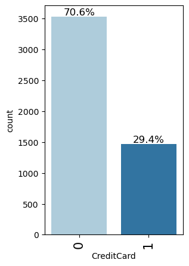

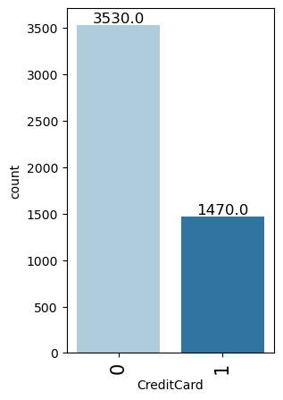

```python
# labeled barplot with percentage
labeled_barplot(df, CREDITCARD, perc=True)
# labeled barplot with count
labeled_barplot(df, CREDITCARD)
```

### Observations on 'CreditCard'

1. There are 70.6% of the customers do not use a credit card issued by any other Bank (excluding All life Bank).
2. There are 29.4% of the customers use a credit card issued by any other Bank (excluding All life Bank).

### Bivariate Analysis

```python
# function to plot stacked barplot
def stacked_barplot(data, predictor, target):
    """
    Print the category counts and plot a stacked bar chart

    data: dataframe
    predictor: independent variable
    target: target variable
    """
    count = data[predictor].nunique()
    sorter = data[target].value_counts().index[-1]
    tab1 = pd.crosstab(data[predictor], data[target], margins=True).sort_values(
        by=sorter, ascending=False
    )
    print(tab1)
    print("-" * 120)
    tab = pd.crosstab(data[predictor], data[target], normalize='index').sort_values(
        by=sorter, ascending=False
    )
    tab.plot(kind='bar', stacked=True, figsize=(count + 5, 5))
    plt.legend(
        loc='lower left', frameon=False,
    )
    plt.legend(loc='upper left', bbox_to_anchor=(1, 1))
    plt.show()
```

```python
### function to plot distributions wrt target
def distribution_plot_wrt_target(data, predictor, target):

    fig, axs = plt.subplots(2, 2, figsize=(12, 10))

    target_uniq = data[target].unique()

    axs[0, 0].set_title('Distribution of target for target=' + str(target_uniq[0]))
    sns.histplot(
        data=data[data[target] == target_uniq[0]],
        x=predictor,
        kde=True,
        ax=axs[0, 0],
        color='teal',
        stat='density',
    )

    axs[0, 1].set_title('Distribution of target for target=' + str(target_uniq[1]))
    sns.histplot(
        data=data[data[target] == target_uniq[1]],
        x=predictor,
        kde=True,
        ax=axs[0, 1],
        color='orange',
        stat='density',
    )

    axs[1, 0].set_title('Boxplot w.r.t target')
    sns.boxplot(data=data, x=target, y=predictor, ax=axs[1, 0], palette='gist_rainbow')

    axs[1, 1].set_title('Boxplot (without outliers) w.r.t target')
    sns.boxplot(
        data=data,
        x=target,
        y=predictor,
        ax=axs[1, 1],
        showfliers=False,
        palette='gist_rainbow',
    )

    plt.tight_layout()
    plt.show()
```

### Correlation check

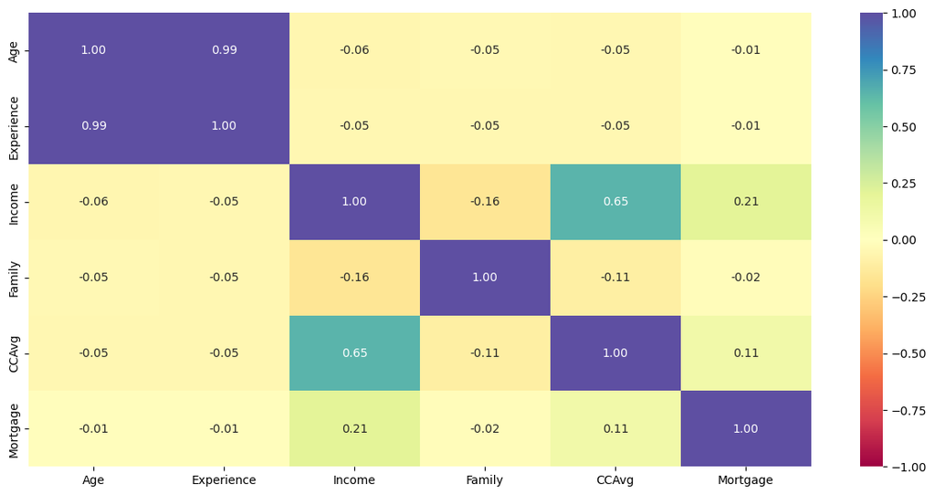

```python
# set the fig size
plt.figure(figsize=(15, 7))
# select only the numeric columns in the DataFrame
df_numeric = df.select_dtypes(include=np.number)
# heatmap
sns.heatmap(df_numeric.corr(), annot=True, vmin=-1, vmax=1, fmt=".2f", cmap='Spectral')
plt.show()
```

### Observations:

1. Age and Experience is highly co-related.
2. CCAvg and Income somewhat co-related.

### Personal Loan vs Age

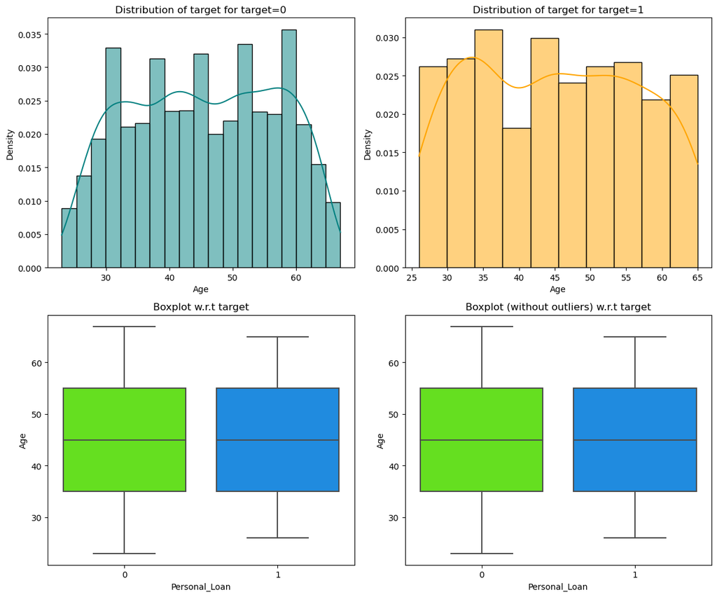

```python
# distribution plot - Personal_Loan vs Age
distribution_plot_wrt_target(df, AGE, PERSONAL_LOAN)
```

### Personal Loan vs CCAvg

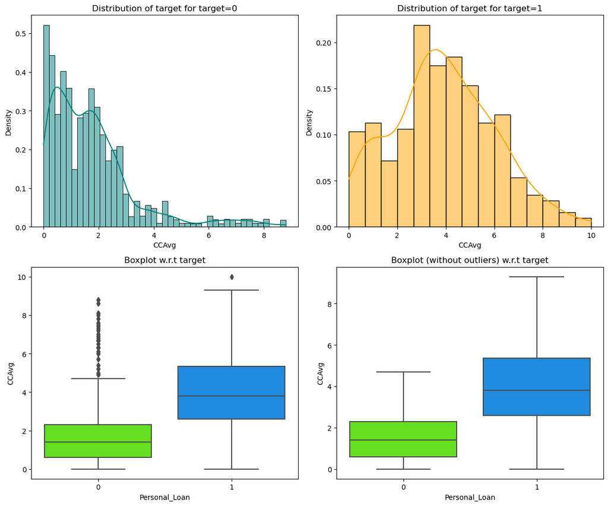

```python
# distribution plot - Personal_Loan vs CCAvg
distribution_plot_wrt_target(df, CCAVG, PERSONAL_LOAN)
```

### Observations:

1. There are outliers with target is 0.
2. It's right skewed.
3. The customers who have high CCAvg, also has Personal loans.

### Personal_Loan vs CD_Account

```
Personal_Loan     0    1   All
CD_Account
All            4520  480  5000
0              4358  340  4698
1               162  140   302
------------------------------------------------------------------------------------------------------------------------
```

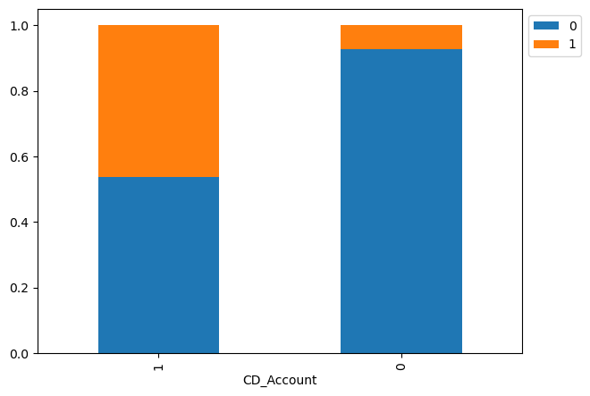

```python
# stacked_barplot - Personal_Loan vs CDAccount
stacked_barplot(df, CD_ACCOUNT, PERSONAL_LOAN)
```

### Observations:

1. The customers with CDAccount also has personal loans.

### Personal_Loan vs CreditCard

```
Personal_Loan     0    1   All
CreditCard
All            4520  480  5000
0              3193  337  3530
1              1327  143  1470
------------------------------------------------------------------------------------------------------------------------
```

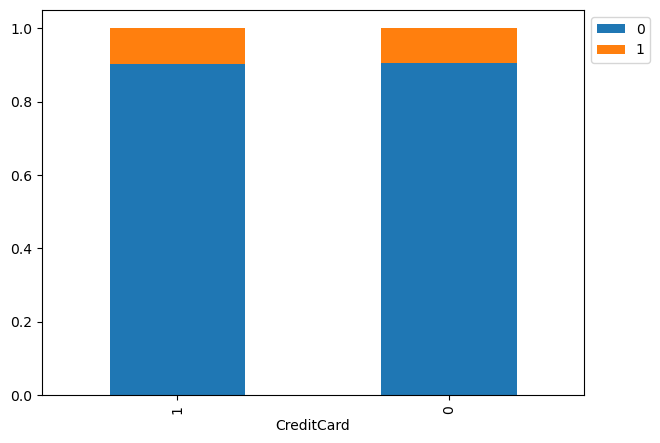

```python
# stacked_barplot - Personal_Loan vs CreditCard
stacked_barplot(df, CREDITCARD, PERSONAL_LOAN)
```

### Observations:

1. There are less number of users with existing personal loan.

### Personal Loan vs Education

```
Personal_Loan     0    1   All
Education
All            4520  480  5000
Professional   1296  205  1501
Graduate       1221  182  1403
Undergraduate  2003   93  2096
------------------------------------------------------------------------------------------------------------------------
```

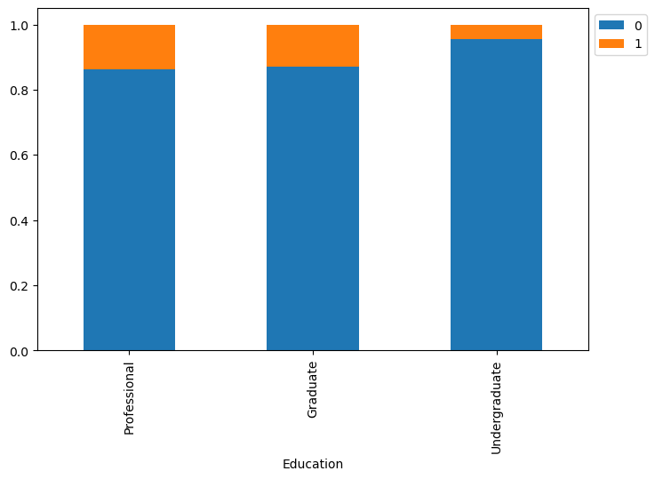

```python
# stacked_barplot - Personal_Loan vs Education
stacked_barplot(df, EDUCATION, PERSONAL_LOAN)
```

### Observations:

1. Professionals tops the list of personal loans followed by Graduate and Undergraduate.

### Personal Loan vs Experience

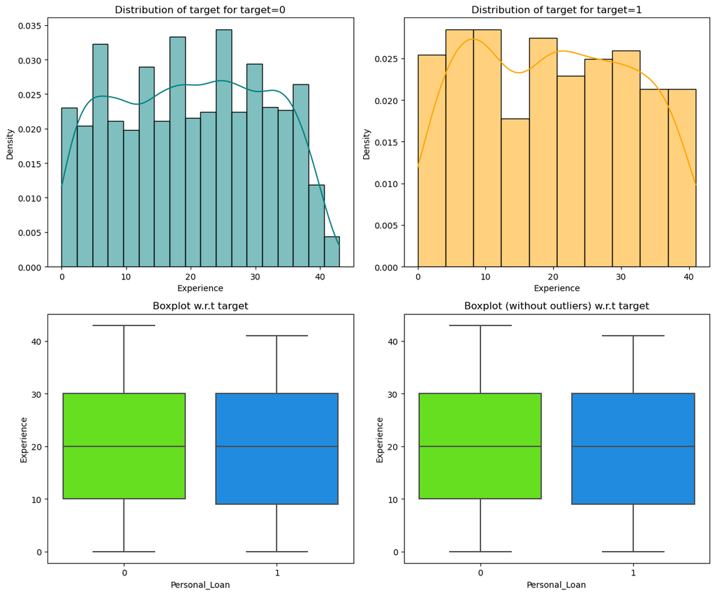

```python
# distribution plot - Personal_Loan vs Experience
distribution_plot_wrt_target(df, EXPERIENCE, PERSONAL_LOAN)
```

### Observations:

1. Average experience is around 20.
2. for both customers with personal loan and without personal loans.

### Personal Loan vs Family

```
Personal_Loan     0    1   All
Family
All            4520  480  5000
4              1088  134  1222
3               877  133  1010
1              1365  107  1472
2              1190  106  1296
------------------------------------------------------------------------------------------------------------------------
```

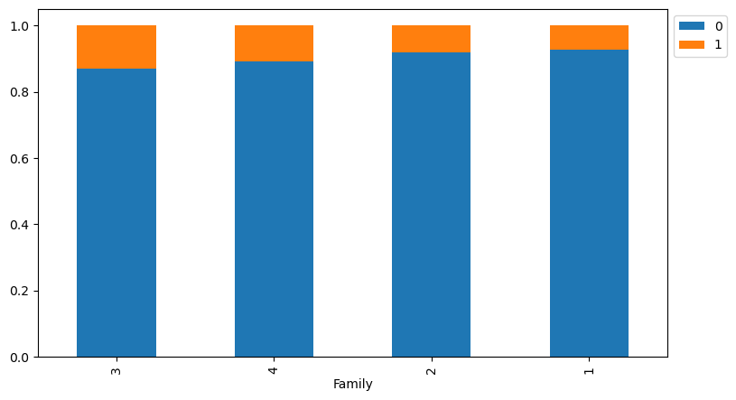

```python
# stacked_barplot - Personal_Loan vs Family
stacked_barplot(df, FAMILY, PERSONAL_LOAN)
```

### Observations:

1. The number of customers with the family size of 4, has the more number of personal loans.
2. The customers with the family size of 3, has more number of personal loans around 14% (133/1010).

### Personal Loan vs Income

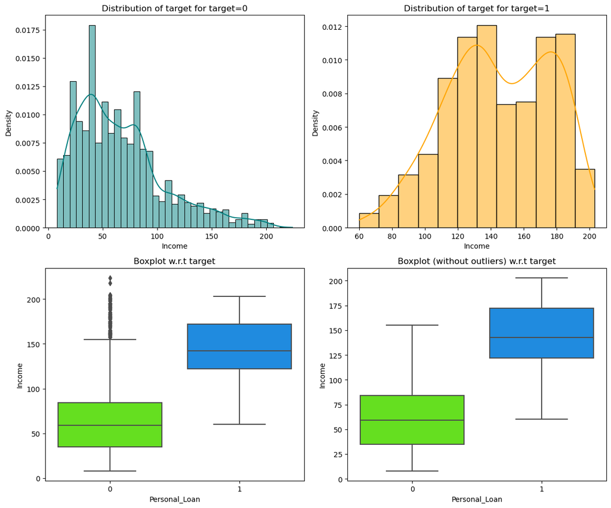

```python
# distributionplot - Personal_Loan vs Income
distribution_plot_wrt_target(df, INCOME, PERSONAL_LOAN)
```

### Personal_Loan vs Online

```
Personal_Loan     0    1   All
Online
All            4520  480  5000
1              2693  291  2984
0              1827  189  2016
------------------------------------------------------------------------------------------------------------------------
```

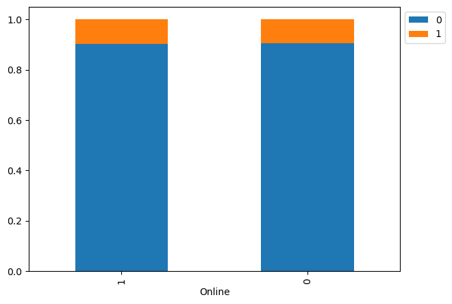

```python
# stacked_barplot - Personal_Loan vs Online
stacked_barplot(df, ONLINE, PERSONAL_LOAN)
```

### Personal_Loan vs Securities_Account

```
Personal_Loan          0    1   All
Securities_Account
All                 4520  480  5000
0                   4058  420  4478
1                    462   60   522
------------------------------------------------------------------------------------------------------------------------
```

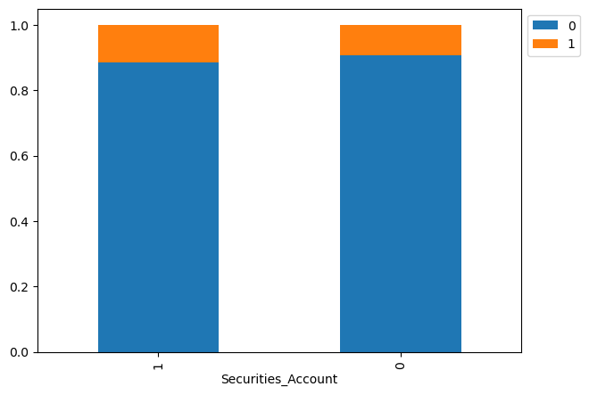

```python
# stacked_barplot - Personal_Loan vs Securities_Account
stacked_barplot(df, SECURITIES_ACCOUNT,PERSONAL_LOAN)
```

### Personal_Loan vs ZIPCode

```
Personal_Loan     0    1   All
ZIPCode
All            4520  480  5000
94             1334  138  1472
92              894   94   988
95              735   80   815
90              636   67   703
91              510   55   565
93              374   43   417
96               37    3    40
------------------------------------------------------------------------------------------------------------------------
```

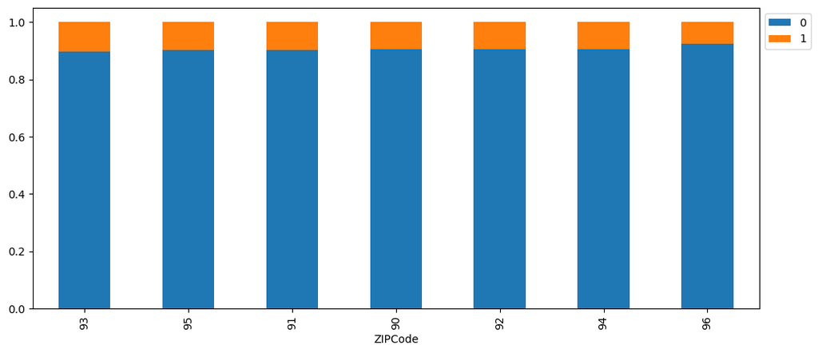

```python
# stacked_barplot - Personal_Loan vs ZIPCode
stacked_barplot(df, ZIPCODE, PERSONAL_LOAN)
```

## Data Preprocessing (contd)

- Missing value treatment (done above)
- Feature engineering (if needed)
- Outlier detection and treatment (if needed)
- Preparing data for modeling
- Any other preprocessing steps (if needed)

### Outlier Detection

```python
Q1 = df.quantile(0.25, numeric_only=True)  # get the 25th percentile. using numeric_only=True to avoid warning
Q3 = df.quantile(0.75, numeric_only=True)  # get the 75th percentile.

IQR = Q3 - Q1               # Inter Quantile Range (75th perentile - 25th percentile)

# Finding lower and upper bounds for all values. All values outside these bounds are outliers
lower = Q1 - 1.5 * IQR
upper = Q3 + 1.5 * IQR
lower,upper
```

```
(Age             5.0
 Experience    -20.0
 Income        -49.5
 Family         -2.0
 CCAvg          -2.0
 Mortgage     -151.5
 dtype: float64,
 Age            85.0
 Experience     60.0
 Income        186.5
 Family          6.0
 CCAvg           5.2
 Mortgage      252.5
 dtype: float64)
```

```python
((df.select_dtypes(include=['float64', 'int64']) < lower)
    |(df.select_dtypes(include=['float64', 'int64']) > upper)
).sum() / len(df) * 100
```

```
Age           0.00
Experience    0.00
Income        1.92
Family        0.00
CCAvg         6.48
Mortgage      5.82
dtype: float64
```

### Data Preparation for Modeling

```python
# preparing independent and dependent variable
X = df.drop([PERSONAL_LOAN, EXPERIENCE], axis=1)
Y = df[PERSONAL_LOAN]
```

### Partition the data into train and test set.

```python
# apply dummies on ZIPCode and Education
X = pd.get_dummies(X, columns=[ZIPCODE, EDUCATION], drop_first=True)

# split data in train and test sets
X_train, X_test, y_train, y_test = train_test_split(X, Y, test_size=0.30, random_state=1)
```

```python
# shape of train data
print('Shape of Training set : ', X_train.shape)
# shape of test data
print('Shape of test set : ', X_test.shape)
print('Percentage of classes in training set:')
# value counts of y train data
print(y_train.value_counts(normalize=True))
print('Percentage of classes in test set:')
# value counts of y test data
print(y_test.value_counts(normalize=True))
```

```
Shape of Training set :  (3500, 17)
Shape of test set :  (1500, 17)
Percentage of classes in training set:
0    0.905429
1    0.094571
Name: Personal_Loan, dtype: float64
Percentage of classes in test set:
0    0.900667
1    0.099333
Name: Personal_Loan, dtype: float64
```

## Model Building

### Model Evaluation Criterion

**Model can make wrong predictions as:**

1. Predicting a customer will take the personal loan but in reality the customer will not take the personal loan - Loss of resources
2. Predicting a customer will not take the personal loan but in reality the customer was going to take the personal loan - Loss of opportunity

**Which case is more important?**

- Losing a potential customer by predicting that the customer will not be taking the personal loan but in reality the customer was going to take the personal loan.

**How to reduce this loss i.e need to reduce False Negatives?**

- Bank would want Recall to be maximized, greater the Recall higher the chances of minimizing false negatives. Hence, the focus should be on increasing Recall or minimizing the false negatives.

First, let's create functions to calculate different metrics and confusion matrix so that we don't have to use the same code repeatedly for each model.

### Model Building

First, let's create functions to calculate different metrics and confusion matrix so that we don't have to use the same code repeatedly for each model.

- The model_performance_classification_sklearn function will be used to check the model performance of models.
- The confusion_matrix_sklearnfunction will be used to plot confusion matrix.

```python
# defining a function to compute different metrics to check performance of a classification model built using sklearn
def model_performance_classification_sklearn(model, predictors, target):
    """
    Function to compute different metrics to check classification model performance

    model: classifier
    predictors: independent variables
    target: dependent variable
    """

    # predicting using the independent variables
    pred = model.predict(predictors)

    acc = accuracy_score(target, pred)  # to compute Accuracy
    recall = recall_score(target, pred)  # to compute Recall
    precision = precision_score(target, pred)  # to compute Precision
    f1 = f1_score(target, pred)  # to compute F1-score

    # creating a dataframe of metrics
    df_perf = pd.DataFrame(
        {'Accuracy': acc, 'Recall': recall, 'Precision': precision, 'F1': f1,},
        index=[0],
    )

    return df_perf
```

```python
def confusion_matrix_sklearn(model, predictors, target):
    """
    To plot the confusion_matrix with percentages

    model: classifier
    predictors: independent variables
    target: dependent variable
    """
    y_pred = model.predict(predictors)
    cm = confusion_matrix(target, y_pred)
    labels = np.asarray(
        [
            ["{0:0.0f}".format(item) + "\n{0:.2%}".format(item / cm.flatten().sum())]
            for item in cm.flatten()
        ]
    ).reshape(2, 2)

    plt.figure(figsize=(6, 4))
    sns.heatmap(cm, annot=labels, fmt="")
    plt.ylabel('True label')
    plt.xlabel('Predicted label')
```

### Build Decision Tree Model

- We will build our model using the DecisionTreeClassifier function. Using default 'gini' criteria to split.

```python
# Initialize the Decision Tree Classifier
model = DecisionTreeClassifier(criterion='gini', random_state=1)
model.fit(X_train, y_train)  ## fit decision tree on train data
```

```
DecisionTreeClassifier(random_state=1)
```

### Checking model performance on training data

```python
# create confusion matrix for train data
confusion_matrix_sklearn(model, X_train, y_train)
```

[output not shown]

```python
# the model performance on train data
decision_tree_perf_train = model_performance_classification_sklearn(model, X_train, y_train)
decision_tree_perf_train
```

|  | Accuracy | Recall | Precision | F1 |
| --- | --- | --- | --- | --- |
| 0 | 1.0 | 1.0 | 1.0 | 1.0 |

### Visualizing the Decision Tree

```python
# list column names
feature_names = list(X_train.columns)
print(feature_names)
```

```
['Age', 'Income', 'Family', 'CCAvg', 'Mortgage', 'Securities_Account', 'CD_Account', 'Online', 'CreditCard', 'ZIPCode_91', 'ZIPCode_92', 'ZIPCode_93', 'ZIPCode_94', 'ZIPCode_95', 'ZIPCode_96', 'Education_Professional', 'Education_Undergraduate']
```

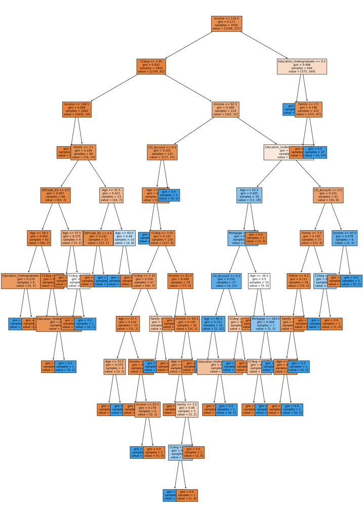

```python
# set the figsize
plt.figure(figsize=(20, 30))
# plot tree
out = tree.plot_tree(
    model,
    feature_names=feature_names,
    filled=True,
    fontsize=9,
    node_ids=False,
    class_names=None,
)
# add arrows to the decision tree split if they are missing
for o in out:
    arrow = o.arrow_patch
    if arrow is not None:
        arrow.set_edgecolor('black')
        arrow.set_linewidth(1)
plt.show()
```

```python
# Text report showing the rules of a decision tree -
print(tree.export_text(model, feature_names=feature_names, show_weights=True))
```

```
|--- Income <= 116.50
|   |--- CCAvg <= 2.95
|   |   |--- Income <= 106.50
|   |   |   |--- weights: [2553.00, 0.00] class: 0
|   |   |--- Income >  106.50
|   |   |   |--- Family <= 3.50
|   |   |   |   |--- ZIPCode_93 <= 0.50
|   |   |   |   |   |--- Age <= 28.50
|   |   |   |   |   |   |--- Education_Undergraduate <= 0.50
|   |   |   |   |   |   |   |--- weights: [0.00, 1.00] class: 1
|   |   |   |   |   |   |--- Education_Undergraduate >  0.50
|   |   |   |   |   |   |   |--- weights: [5.00, 0.00] class: 0
|   |   |   |   |   |--- Age >  28.50
|   |   |   |   |   |   |--- CCAvg <= 2.20
|   |   |   |   |   |   |   |--- weights: [48.00, 0.00] class: 0
|   |   |   |   |   |   |--- CCAvg >  2.20
|   |   |   |   |   |   |   |--- Education_Professional <= 0.50
|   |   |   |   |   |   |   |   |--- weights: [7.00, 0.00] class: 0
|   |   |   |   |   |   |   |--- Education_Professional >  0.50
|   |   |   |   |   |   |   |   |--- weights: [0.00, 1.00] class: 1
|   |   |   |   |--- ZIPCode_93 >  0.50
|   |   |   |   |   |--- Age <= 37.50
|   |   |   |   |   |   |--- weights: [2.00, 0.00] class: 0
|   |   |   |   |   |--- Age >  37.50
|   |   |   |   |   |   |--- CCAvg <= 1.10
|   |   |   |   |   |   |   |--- weights: [1.00, 0.00] class: 0
|   |   |   |   |   |   |--- CCAvg >  1.10
|   |   |   |   |   |   |   |--- weights: [0.00, 1.00] class: 1
|   |   |   |--- Family >  3.50
|   |   |   |   |--- Age <= 32.50
|   |   |   |   |   |--- ZIPCode_92 <= 0.50
|   |   |   |   |   |   |--- weights: [12.00, 0.00] class: 0
|   |   |   |   |   |--- ZIPCode_92 >  0.50
|   |   |   |   |   |   |--- weights: [0.00, 1.00] class: 1
|   |   |   |   |--- Age >  32.50
|   |   |   |   |   |--- Age <= 60.00
|   |   |   |   |   |   |--- weights: [0.00, 6.00] class: 1
|   |   |   |   |   |--- Age >  60.00
|   |   |   |   |   |   |--- weights: [4.00, 0.00] class: 0
|   |--- CCAvg >  2.95
```

[output cut: 90 more lines]

```
|   |   |   |   |   |   |--- CCAvg >  4.20
|   |   |   |   |   |   |   |--- weights: [1.00, 0.00] class: 0
|   |   |   |   |--- CD_Account >  0.50
|   |   |   |   |   |--- Income <= 93.50
|   |   |   |   |   |   |--- weights: [1.00, 0.00] class: 0
|   |   |   |   |   |--- Income >  93.50
|   |   |   |   |   |   |--- weights: [0.00, 5.00] class: 1
|--- Income >  116.50
|   |--- Education_Undergraduate <= 0.50
|   |   |--- weights: [0.00, 222.00] class: 1
|   |--- Education_Undergraduate >  0.50
|   |   |--- Family <= 2.50
|   |   |   |--- weights: [375.00, 0.00] class: 0
|   |   |--- Family >  2.50
|   |   |   |--- weights: [0.00, 47.00] class: 1
```

```python
# importance of features in the tree building ( The importance of a feature is computed as the
# (normalized) total reduction of the criterion brought by that feature. It is also known as the Gini importance )
print(
    pd.DataFrame(
        model.feature_importances_, columns=['Imp'], index=X_train.columns
    ).sort_values(by='Imp', ascending=False)
)
```

```
                              Imp
Education_Undergraduate  0.403732
Income                   0.304761
Family                   0.161717
CCAvg                    0.053107
Age                      0.036035
CD_Account               0.025711
Mortgage                 0.005557
Education_Professional   0.005144
ZIPCode_92               0.003080
ZIPCode_93               0.000594
Online                   0.000561
Securities_Account       0.000000
ZIPCode_91               0.000000
ZIPCode_94               0.000000
ZIPCode_95               0.000000
ZIPCode_96               0.000000
CreditCard               0.000000
```

### Feature importance

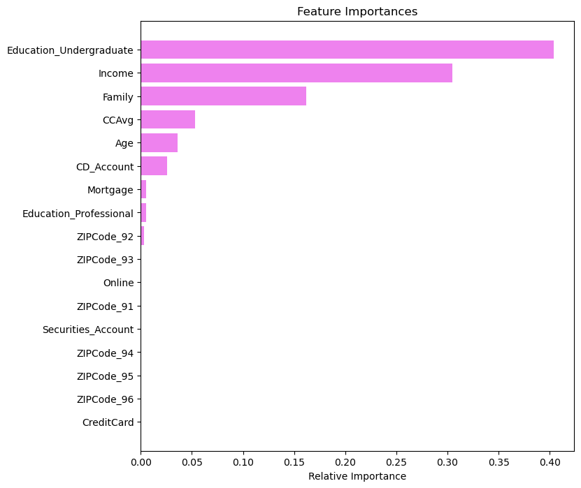

```python
# feature importances
importances = model.feature_importances_
# sort
indices = np.argsort(importances)

# set parameters and plot
plt.figure(figsize=(8, 8))
plt.title('Feature Importances')
plt.barh(range(len(indices)), importances[indices], color='violet', align='center')
plt.yticks(range(len(indices)), [feature_names[i] for i in indices])
plt.xlabel('Relative Importance')
plt.show()
```

### Checking model performance on test data

```python
# create confusion matrix for test data
confusion_matrix_sklearn(model, X_test, y_test)
```

[output not shown]

```python
# the model performance on test data
decision_tree_perf_test = model_performance_classification_sklearn(model, X_test, y_test)
decision_tree_perf_test
```

|  | Accuracy | Recall | Precision | F1 |
| --- | --- | --- | --- | --- |
| 0 | 0.981333 | 0.899329 | 0.911565 | 0.905405 |

### Model Performance Improvement

### Pre-Pruning

```python
# Choose the type of classifier.
estimator = DecisionTreeClassifier(random_state=1)

# Grid of parameters to choose from
parameters = {
    'max_depth': np.arange(6, 15),
    'min_samples_leaf': [1, 2, 5, 7, 10],
    'max_leaf_nodes': [2, 3, 5, 10],
}

# Type of scoring used to compare parameter combinations
acc_scorer = make_scorer(recall_score)

# Run the grid search
grid_obj = GridSearchCV(estimator, parameters, scoring=acc_scorer, cv=5)
grid_obj = grid_obj.fit(X_train, y_train)

# Set the clf to the best combination of parameters
estimator = grid_obj.best_estimator_

estimator.fit(X_train, y_train) ## fit model on train data
```

```
DecisionTreeClassifier(max_depth=6, max_leaf_nodes=10, random_state=1)
```

### Checking performance on training data

```python
# create confusion matrix for train data
confusion_matrix_sklearn(model, X_train, y_train)
```

[output not shown]

```python
# check performance on train data
decision_tree_tune_perf_train = model_performance_classification_sklearn(model, X_train, y_train)
decision_tree_tune_perf_train
```

[output not shown]

### Visualizing the Decision Tree

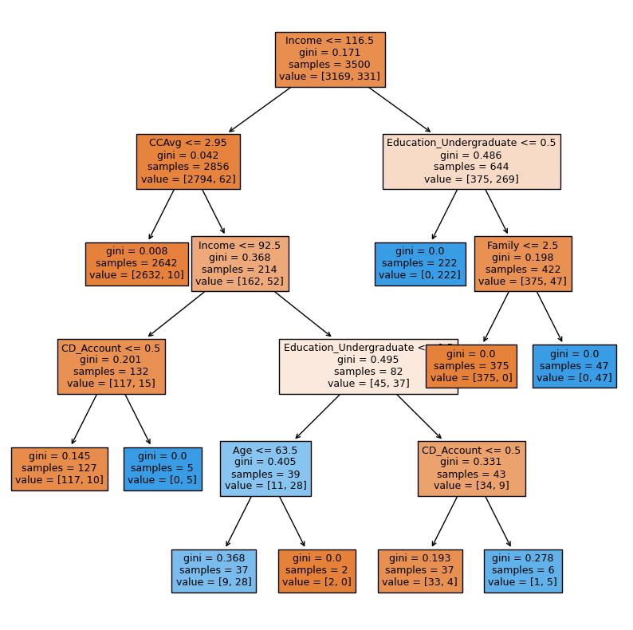

```python
# set figsize(10,10)
plt.figure(figsize=(10, 10))
# plot tree
out = tree.plot_tree(
    estimator,
    feature_names=feature_names,
    filled=True,
    fontsize=9,
    node_ids=False,
    class_names=None,
)
# below code will add arrows to the decision tree split if they are missing
for o in out:
    arrow = o.arrow_patch
    if arrow is not None:
        arrow.set_edgecolor('black')
        arrow.set_linewidth(1)
plt.show()
```

```python
# Text report showing the rules of a decision tree -
print(tree.export_text(estimator, feature_names=feature_names, show_weights=True))
```

```
|--- Income <= 116.50
|   |--- CCAvg <= 2.95
|   |   |--- weights: [2632.00, 10.00] class: 0
|   |--- CCAvg >  2.95
|   |   |--- Income <= 92.50
|   |   |   |--- CD_Account <= 0.50
|   |   |   |   |--- weights: [117.00, 10.00] class: 0
|   |   |   |--- CD_Account >  0.50
|   |   |   |   |--- weights: [0.00, 5.00] class: 1
|   |   |--- Income >  92.50
|   |   |   |--- Education_Undergraduate <= 0.50
|   |   |   |   |--- Age <= 63.50
|   |   |   |   |   |--- weights: [9.00, 28.00] class: 1
|   |   |   |   |--- Age >  63.50
|   |   |   |   |   |--- weights: [2.00, 0.00] class: 0
|   |   |   |--- Education_Undergraduate >  0.50
|   |   |   |   |--- CD_Account <= 0.50
|   |   |   |   |   |--- weights: [33.00, 4.00] class: 0
|   |   |   |   |--- CD_Account >  0.50
|   |   |   |   |   |--- weights: [1.00, 5.00] class: 1
|--- Income >  116.50
|   |--- Education_Undergraduate <= 0.50
|   |   |--- weights: [0.00, 222.00] class: 1
|   |--- Education_Undergraduate >  0.50
|   |   |--- Family <= 2.50
|   |   |   |--- weights: [375.00, 0.00] class: 0
|   |   |--- Family >  2.50
|   |   |   |--- weights: [0.00, 47.00] class: 1
```

```python
# importance of features in the tree building ( The importance of a feature is computed as the
# (normalized) total reduction of the criterion brought by that feature. It is also known as the Gini importance )
print(
    pd.DataFrame(
        estimator.feature_importances_, columns=['Imp'], index=X_train.columns
    ).sort_values(by='Imp', ascending=False)
)
```

```
                              Imp
Education_Undergraduate  0.446191
Income                   0.327387
Family                   0.155083
CCAvg                    0.042061
CD_Account               0.025243
Age                      0.004035
Securities_Account       0.000000
Online                   0.000000
Mortgage                 0.000000
ZIPCode_91               0.000000
ZIPCode_92               0.000000
ZIPCode_93               0.000000
ZIPCode_94               0.000000
ZIPCode_95               0.000000
ZIPCode_96               0.000000
Education_Professional   0.000000
CreditCard               0.000000
```

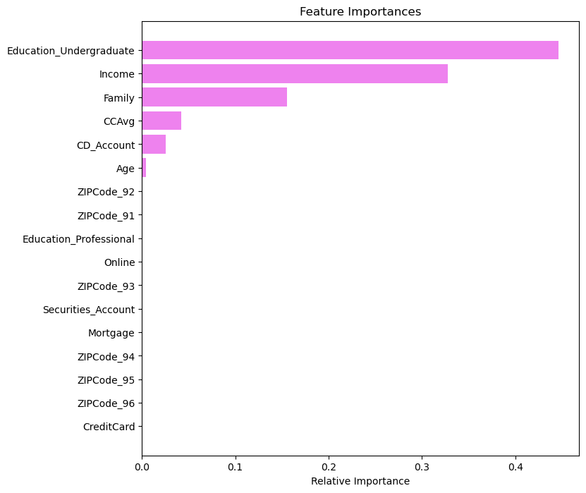

```python
# feature importances
importances = estimator.feature_importances_
# sort
indices = np.argsort(importances)

# set parameters and plot
plt.figure(figsize=(8, 8))
plt.title('Feature Importances')
plt.barh(range(len(indices)), importances[indices], color='violet', align='center')
plt.yticks(range(len(indices)), [feature_names[i] for i in indices])
plt.xlabel('Relative Importance')
plt.show()
```

**Checking performance on test data**

```python
# create confusion matrix for test data
confusion_matrix_sklearn(model, X_test, y_test)
```

[output not shown]

```python
# the model performance on test data
decision_tree_tune_perf_test = model_performance_classification_sklearn(model, X_test, y_test)
decision_tree_tune_perf_test
```

[output not shown]